# Homework 10

Rachel Hall

April 3, 2024

#### Question 1

##### Using a for loop, write a function to calculate the number of zeroes in a numeric vector. Before entering the loop, set up a counter variable counter <- 0. Inside the loop, add 1 to counter each time you have a zero in the vector. Finally, use return(counter) for the output.

```r
number_zs <- function(z = round(runif(100), digits=0)) {
  counter <- 0
  for (i in seq_along(z)) {
    if (z[i]==0) counter <- counter+1}
  return(counter)}
number_zs()
```

```
## [1] 54
```

#### Question 2

##### Use subsetting instead of a loop to rewrite the function as a single line of code.

```r
number_zs2 <- function(z= round(runif(100), digits = 0)) {
  print(counter <-sum(z==0))}
number_zs2()
```

```
## [1] 54
```

#### Question 3

##### Write a function that takes as input two integers representing the number of rows and columns in a matrix. The output is a matrix of these dimensions in which each element is the product of the row number x the column number.

```r
product_matrix <- function(r, c) {

  m <- matrix(NA, nrow = r, ncol = c)
  for (i in 1:nrow(m)) {
    for (j in 1:ncol(m)) {
      m[i,j] <- i*j}}
  print(m)}

product_matrix(r=3, c=5)
```

```
##      [,1] [,2] [,3] [,4] [,5]
## [1,]    1    2    3    4    5
## [2,]    2    4    6    8   10
## [3,]    3    6    9   12   15
```

#### Question 4

##### 4a. Simulate a dataset with 3 groups of data, each group drawn from a distribution with a different mean. The final data frame should have 1 column for group and 1 column for the response variable.

```r
Group <- c(rep("Control",10),rep("Treatment1",10),rep("Treatment2",10))
Data <- c(rnorm(10,mean = 7, sd = 3),
          rnorm(10,mean = 10, sd = 2),
          rnorm(10,mean = 20, sd = 4))
df <- data.frame(Group,Data)

head(df)
```

```
##     Group     Data
## 1 Control 9.964790
## 2 Control 5.779853
## 3 Control 8.446109
## 4 Control 3.613645
## 5 Control 9.979669
## 6 Control 6.889895
```

##### 4b. Write a custom function that 1) reshuffles the response variable, and 2) calculates the mean of each group in the reshuffled data. Store the means in a vector of length 3.

```r
shuffle_data <- function(df) {
   df <- data.frame(Group,Data)
    df[,2]<-sample(df$Data) # reshuffle data
   df<-group_by(df, Group)
  mean<-summarize(df,Mean=mean(Data))
  return(mean)
}
print(MeanTable<-shuffle_data())
```

```
## # A tibble: 3 × 2
##   Group       Mean
##   <chr>      <dbl>
## 1 Control     13.7
## 2 Treatment1  10.6
## 3 Treatment2  10.7
```

```r
print(MeanVals<-MeanTable[,2])
```

```
## # A tibble: 3 × 1
##    Mean
##   <dbl>
## 1  13.7
## 2  10.6
## 3  10.7
```

##### 4c. Use a for loop to repeat the function in b 100 times. Store the results in a data frame that has 1 column indicating the replicate number and 1 column for each new group mean, for a total of 4 columns.

```r
d_new <- data.frame(ID=1:100,
                      Control_Mean=NA,
                      Trt1_Mean=NA,
                      Trt2_Mean=NA)

for (i in 1:100) {
  new_means <- shuffle_data(df)
  d_new[i,2] <- new_means[1,2]
  d_new[i,3] <- new_means[2,2]
  d_new[i,4] <- new_means[3,2]
}
print(d_new)
```

```
##      ID Control_Mean Trt1_Mean Trt2_Mean
## 1     1    12.358949 12.300996 10.383577
## 2     2    11.729710  9.880416 13.433395
## 3     3    14.298512 11.619686  9.125324
## 4     4    14.241541 12.390307  8.411674
## 5     5     9.938565 12.330835 12.774123
## 6     6    10.479301 14.425960 10.138260
## 7     7    11.132441 11.602368 12.308713
## 8     8    11.706328 10.013865 13.323329
## 9     9     9.296968 11.406605 14.339950
## 10   10    12.773606  9.376854 12.893062
## 11   11    11.068660 12.088196 11.886667
## 12   12    11.226054 13.211051 10.606417
## 13   13    14.213738 11.202206  9.627578
## 14   14    10.772255 12.434909 11.836359
```

[output cut: 86 more lines]

##### 4d. Use qplot() to create a histogram of the means for each reshuffled group. Or, if you want a challenge, use ggplot() to overlay all 3 histograms in the same figure. How do the distributions of reshuffled means compare to the original means?

```r
g1 <- ggplot(data=d_new) + aes(x=Control_Mean) + geom_histogram(fill="lightskyblue",color="cornflowerblue")

g2 <- ggplot(data=d_new) + aes(x=Trt1_Mean) + geom_histogram(fill="darkseagreen1",color="darkseagreen4")

g3 <- ggplot(data=d_new) + aes(x=Trt2_Mean) + geom_histogram(fill="plum1",color="orchid")
```

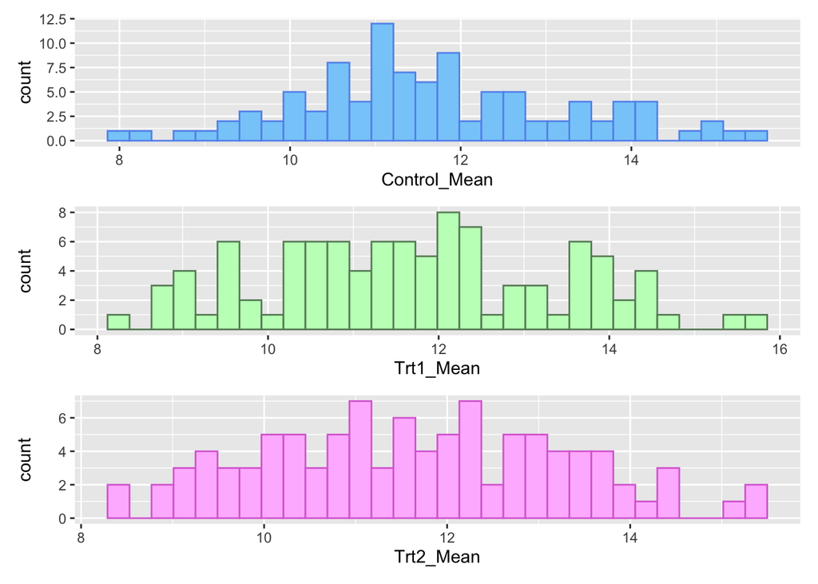

```r
g1 + g2 + g3 + plot_layout(ncol=1)
```